# Data Processing of Singapore’s International Visitor Arrivals Data from 1978 to 2019

Lim Lay Hoon

16 October 2019

### **Introduction**

Singapore’s international visitor arrivals data used here is compiled by the [Singapore Tourism Board](https://www.stb.gov.sg/content/stb/en.html). This data, in excel format, can be downloaded from [Singapore Department of Statistics](https://www.singstat.gov.sg/find-data/search-by-theme/industry/tourism/latest-data).

There are 3 worksheets in the excel file: T1, T2 and T3.

- Monthly International Visitor Arrivals By Inbound Tourism Markets (T1)
- Monthly International Visitor Arrivals By Sex And Age Group (T2)
- Monthly International Visitor Arrivals By Length Of Stay (T3)

These data are compiled from the Disembarkation/Embarkation Forms (IMM 27) completed by all visitors arriving in Singapore at the points of entry. These data exclude arrivals of Malaysians by land. In addition, the arrivals data from worksheet T3 only captures data from visitors who left Singapore in less than a year.

### **Monthly International Visitor Arrivals By Inbound Tourism Markets (T1)**

##### **Raw Data**

Below is an extract from worksheet T1. The monthly arrival data is compile at global, regional and country levels from 1978 Jan to 2019 Jul.

```
Variables                                                        1978 Jan  1978 Feb  ... ...   2019 Jul  Missing Value
Total International Visitor Arrivals By Inbound Tourism Markets   167,016   147,954  ... ...  1,801,365             0%
        Southeast Asia                                             64,500    57,650  ... ...    617,321             0%
            Brunei Darussalam                                          na        na  ... ...      5,880            43%
            Indonesia                                                  na        na  ... ...    294,001            43%
            Malaysia                                                   na        na  ... ...     92,966            43%
            Myanmar                                                    na        na  ... ...     14,805            46%
            Philippines                                                na        na  ... ...     68,839            43%
            Thailand                                                   na        na  ... ...     51,833            43%
            Vietnam                                                    na        na  ... ...     78,465            26%
            Other Markets In Southeast Asia                            na        na  ... ...     10,532            94%
        Greater China                                                  na        na  ... ...    498,539            94%
            China                                                      56         7  ... ...    389,219             0%
            Hong Kong SAR                                           3,148     5,805  ... ...     50,788             0%
            Taiwan                                                  1,956     1,659  ... ...     55,299             0%
            Other Markets In Greater China                             na        na  ... ...      3,233            94%
        North Asia                                                     na        na  ... ...    130,455            94%
            Japan                                                  18,652    20,394  ... ...     71,345             0%
            South Korea                                               518       493  ... ...     59,088             0%
            Other Markets In North Asia                                na        na  ... ...         22            94%
        South Asia                                                  5,870     5,306  ... ...    138,086             0%
            Bangladesh                                                251       318  ... ...     12,559             0%
            India                                                   3,383     3,493  ... ...    111,996             0%
            Pakistan                                                  656       565  ... ...      2,580             0%
            Sri Lanka                                                 826       681  ... ...      7,767             0%
            Other Markets In South Asia                               754       249  ... ...      3,184             0%
        West Asia                                                   1,420     1,455  ... ...     20,601             0%
            Iran                                                      304       219  ... ...        413             0%
            Israel                                                     na        na  ... ...      1,866            94%
            Kuwait                                                     58       128  ... ...      1,663             0%
            Saudi Arabia                                              367       389  ... ...      2,489             0%
            United Arab Emirates                                      216       224  ... ...      9,557             0%
            Other Markets In West Asia                                 na        na  ... ...      4,613            94%
        Americas                                                   10,105     9,996  ... ...     88,545             0%
            Canada                                                  1,328     1,434  ... ...     10,250             0%
            USA                                                     8,362     8,251  ... ...     71,239             0%
            Other Markets In Americas                                  na        na  ... ...      7,056            94%
        Europe                                                     25,643    26,929  ... ...    172,958             0%
            Belgium & Luxembourg                                       na        na  ... ...      4,478             7%
            Denmark                                                   551       580  ... ...      5,406             0%
```

[output cut: 8 more lines]

```
            Spain                                                      na        na  ... ...      6,994            26%
            Sweden                                                    837       704  ... ...      4,197             0%
            Switzerland                                             2,185     1,596  ... ...      9,684             0%
            United Kingdom                                          8,512     9,381  ... ...     43,845             0%
            Other Markets In Europe                                    na        na  ... ...     19,586            94%
        Oceania                                                    32,710    17,189  ... ...    127,315             0%
            Australia                                              28,421    13,982  ... ...    107,352             0%
            New Zealand                                             3,612     2,521  ... ...     17,918             0%
            Other Markets In Oceania                                  677       686  ... ...      2,045             0%
        Africa                                                        587       354  ... ...      7,545             0%
            Egypt                                                      na        na  ... ...        704            94%
            Mauritius                                                  na        na  ... ...      1,178            94%
            South Africa (Rep Of)                                      na        na  ... ...      2,900            94%
            Other Markets In Africa                                    na        na  ... ...      2,763            94%
        Others                                                      1,807       657  ... ...          0             0%
```

The last column shows the percentages of missing arrivals data (na) observed in the dataset.

- The variable “Total International Visitor Arrivals By Inbound Tourism Markets” captures the monthly arrivals data at global level. There is no missing arrivals data at this level.
- There are 2 out of 10 regions with missing arrivals data. They are the Greater China and the North Asia. Both have 94% of their arrivals data missing. However, the arrivals data from the countries in these two regions are mostly available. Hence, one possible way to replace these missing data is by summing up the arrivals data from the countries in these two regions.
- There are 22 out of 51 countries with missing arrivals data. Hence, to compare the arrivals data at the country level meaningfully, only those years where most of the arrivals data are available should be used.

##### **Processed Data**

With the missing arrivals data for the Greater China and North Asia regions replaced, the arrival data from worksheet T1 is split and re-organised into global, regional and country levels. Below are the extracts of the transformed data.

```
Monthly International Visitor Arrivals:

Month     Arrivals
Jan 1978    167016
Feb 1978    147954
Mar 1978    163199
Apr 1978    162400
...            ...
...            ...
Jun 2019   1551170
Jul 2019   1801365

Monthly International Visitor Arrivals By Regional:

Region          Month     Arrivals
Africa          Jan 1978       587
Africa          Feb 1978       354
Africa          Mar 1978       405
Africa          Apr 1978       736
...             ...            ...
...             ...            ...
West Asia       Jun 2019     14872
West Asia       Jul 2019     20601

Monthly International Visitor Arrivals By Country:

Country                          Region          Month     Arrivals
Egypt                            Africa          Jan 1978        NA
Egypt                            Africa          Feb 1978        NA
Egypt                            Africa          Mar 1978        NA
Egypt                            Africa          Apr 1978        NA
...                              ...             ...            ...
...                              ...             ...            ...
United Arab Emirates             West Asia       Jun 2019      6917
United Arab Emirates             West Asia       Jul 2019      9557
```

##### **Comparing Regional Arrivals Data with Global Arrivals Data**

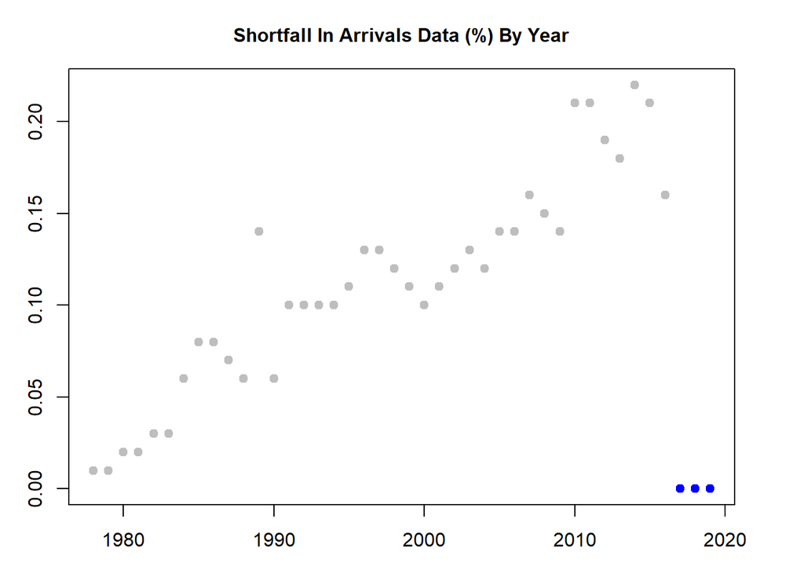

The plot above shows the shortfall in the total number of arrivals captured at the regional level.

- From year 1978 to 2016 (in grey), there is shortfall of not more than 0.22% in the total number of arrivals captured at the regional level yearly.
- From year 2017 to 2019 (in blue), the regional arrivals data tallies with the global arrivals data yearly.

##### **Comparing Country Arrivals Data with Global Arrivals Data**

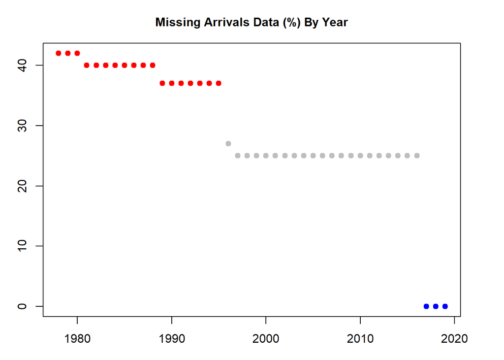

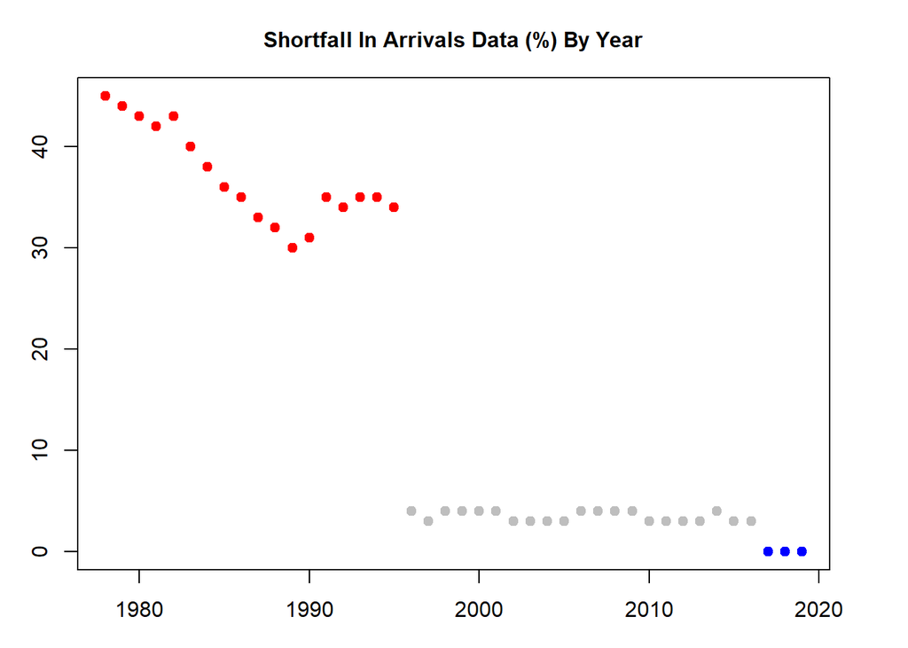

The plots above show the percentages of missing arrivals data at the country level and the shortfall in the total number of arrivals captured at the country level.

- From year 1978 to 1995 (in red), the percentage of missing data is between 37% and 42% yearly, while the shortfall in arrivals data is between 30% and 45% yearly.
- From year 1996 to 2016 (in grey), the percentage of missing data is between 25% and 27% yearly, while the shortfall in arrivals data is between 3% and 4% yearly.
- From year 2017 to 2019 (in blue), there is no missing arrivals data. The arrivals data captured at the country level tallies with the global arrivals data yearly.

Below are the countries with missing arrivals data from year 1978 to 1995.

```
Country                          Missing Value
Brunei Darussalam                         100%
Egypt                                     100%
Indonesia                                 100%
Israel                                    100%
Malaysia                                  100%
Mauritius                                 100%
Myanmar                                   100%
Other Markets In Africa                   100%
Other Markets In Americas                 100%
Other Markets In Europe                   100%
Other Markets In Greater China            100%
Other Markets In North Asia               100%
Other Markets In Southeast Asia           100%
Other Markets In West Asia                100%
Philippines                               100%
Rep Of Ireland                            100%
Russian Federation                        100%
South Africa (Rep Of)                     100%
Thailand                                  100%
Spain                                      61%
Vietnam                                    61%
Belgium & Luxembourg                       17%
```

Below are the countries with missing arrivals data from year 1996 to 2016.

```
Country                          Missing Value
Egypt                                     100%
Israel                                    100%
Mauritius                                 100%
Other Markets In Africa                   100%
Other Markets In Americas                 100%
Other Markets In Europe                   100%
Other Markets In Greater China            100%
Other Markets In North Asia               100%
Other Markets In Southeast Asia           100%
Other Markets In West Asia                100%
Rep Of Ireland                            100%
Russian Federation                        100%
South Africa (Rep Of)                     100%
Myanmar                                     5%
```

### **Monthly International Visitor Arrivals By Sex And Age Group (T2)**

##### **Raw Data**

Below is the data from worksheet T2. The monthly arrival data is compiled at global level, by sex and by age group from 2019 Feb to 2019 Jul.

```
Variables        2019 Feb   2019 Mar   2019 Apr   2019 May   2019 Jun   2019 Jul
Total           1,499,046  1,564,642  1,596,631  1,487,676  1,551,170  1,801,365
Males             738,730    769,417    773,968    723,245    752,981    871,990
Females           760,316    795,225    822,663    764,431    798,189    929,375
Under 15 Years    144,422    101,953    158,894    126,553    174,994    262,680
15-19 Years        40,839     38,424     43,697     43,830     71,421    102,167
20-24 Years        96,595     86,146     83,077     85,953    106,216    134,685
25-34 Years       312,335    330,417    346,562    326,161    325,350    352,035
35-44 Years       294,017    296,238    320,006    305,545    311,844    376,542
45-54 Years       236,913    260,199    259,851    248,868    249,306    284,118
55-64 Years       210,100    259,431    225,639    213,805    194,152    182,916
65 & Over         163,825    191,834    158,905    136,961    117,887    106,222
Not Stated              -          -          -          -          -          -
```

##### **Processed Data**

The arrival data from worksheet T2 is split and re-organised into 3 different tables. Below are the extracts of the transformed data.

```
Monthly International Visitor Arrivals:

Month     Arrivals
Feb 2019   1499046
Mar 2019   1564642
Apr 2019   1596631
May 2019   1487676
Jun 2019   1551170
Jul 2019   1801365

Monthly International Visitor Arrivals By Sex:

Sex     Month     Arrivals
Male    Feb 2019    738730
Female  Feb 2019    760316
Male    Mar 2019    769417
Female  Mar 2019    795225
Male    Apr 2019    773968
Female  Apr 2019    822663
Male    May 2019    723245
Female  May 2019    764431
Male    Jun 2019    752981
Female  Jun 2019    798189
Male    Jul 2019    871990
Female  Jul 2019    929375

Monthly International Visitor Arrivals By Age Group:

Age Group       Month     Arrivals
Under 15 Years  Feb 2019    144422
15-19 Years     Feb 2019     40839
20-24 Years     Feb 2019     96595
25-34 Years     Feb 2019    312335
35-44 Years     Feb 2019    294017
45-54 Years     Feb 2019    236913
55-64 Years     Feb 2019    210100
65 & Over       Feb 2019    163825
...             ...            ...
...             ...            ...
Under 15 Years  Jul 2019    262680
15-19 Years     Jul 2019    102167
20-24 Years     Jul 2019    134685
25-34 Years     Jul 2019    352035
35-44 Years     Jul 2019    376542
45-54 Years     Jul 2019    284118
55-64 Years     Jul 2019    182916
65 & Over       Jul 2019    106222
```

##### **Comparing Global Arrivals Data from T2 with Global Arrivals Data from T1**

The global arrivals data from T2 tallies with that from T1.

```
Month     Global Arrivals from T2 (A)  Global Arrivals from T1 (B)  (A)-(B)
Feb 2019                      1499046                      1499046        0
Mar 2019                      1564642                      1564642        0
Apr 2019                      1596631                      1596631        0
May 2019                      1487676                      1487676        0
Jun 2019                      1551170                      1551170        0
Jul 2019                      1801365                      1801365        0
```

##### **Comparing Arrivals Data By Sex With Global Arrivals Data from T2**

The arrivals data captured by sex tallies with the global arrivals data from T2.

```
Month     Arrivals By Sex (A)  Global Arrivals from T2 (B)  (A)-(B)
Feb 2019              1499046                      1499046        0
Mar 2019              1564642                      1564642        0
Apr 2019              1596631                      1596631        0
May 2019              1487676                      1487676        0
Jun 2019              1551170                      1551170        0
Jul 2019              1801365                      1801365        0
```

##### **Comparing Arrivals Data By Age Group With Global Arrivals Data from T2**

The arrivals data captured by age group tallies with the global arrivals data from T2.

```
Month     Arrivals By Age Group (A)  Global Arrivals from T2 (B)  (A)-(B)
Feb 2019                    1499046                      1499046        0
Mar 2019                    1564642                      1564642        0
Apr 2019                    1596631                      1596631        0
May 2019                    1487676                      1487676        0
Jun 2019                    1551170                      1551170        0
Jul 2019                    1801365                      1801365        0
```

### **Monthly International Visitor Arrivals By Length Of Stay (T3)**

##### **Raw Data**

Below is the data from worksheet T3. The monthly arrival data is compile at global level and by length of stay from 2019 Feb to 2019 Jul.

```
Variables                                      2019 Feb   2019 Mar   2019 Apr   2019 May   2019 Jun   2019 Jul
Total International Visitor Arrivals(Number)  1,465,807  1,529,003  1,493,273  1,464,108  1,505,063  1,722,731
        Under 1 Day(Number)                     319,811    346,184    332,281    311,706    320,916    329,743
        1 Day(Number)                           282,717    351,752    322,107    294,633    291,319    319,227
        2 Days(Number)                          222,942    247,654    233,894    223,258    230,968    278,017
        3 Days(Number)                          210,395    224,626    224,875    226,927    228,147    274,556
        4 Days(Number)                          155,296    133,196    140,430    150,404    153,375    190,704
        5 Days(Number)                           91,453     68,691     75,191     81,069     84,999    114,243
        6 Days(Number)                           50,631     39,633     41,983     44,984     48,565     61,964
        7 Days(Number)                           29,817     25,313     27,392     25,954     31,027     36,816
        8-10 Days(Number)                        34,277     29,512     32,415     30,278     36,353     42,267
        11-14 Days(Number)                       20,149     18,459     18,857     20,036     23,127     25,733
        15 Days & Over(Number)                   48,319     43,983     43,848     54,859     56,267     49,461
        15-29 Days(Number)                       35,595     31,235     32,255     39,462     38,544     37,933
        30-59 Days(Number)                        9,342      8,710      8,229     11,709     13,541      8,357
        60 Days & Over(Number)                    3,382      4,038      3,364      3,688      4,182      3,171
Average Length Of Stay (Days)(Day)                  3.5        3.1        3.2        3.5        3.6        3.4
```

##### **Processed Data**

The arrival data from worksheet T3 is split and re-organised into 2 different tables. Below are the extracts of the transformed data.

```
Monthly International Visitor Arrivals:

Month     Arrivals
Feb 2019   1465807
Mar 2019   1529003
Apr 2019   1493273
May 2019   1464108
Jun 2019   1505063
Jul 2019   1722731

Monthly International Visitor Arrivals By Length of Stay:

Length Of Stay          Month     Arrivals
Under 1 Day(Number)     Feb 2019    319811
1 Day(Number)           Feb 2019    282717
2 Days(Number)          Feb 2019    222942
3 Days(Number)          Feb 2019    210395
4 Days(Number)          Feb 2019    155296
5 Days(Number)          Feb 2019     91453
6 Days(Number)          Feb 2019     50631
7 Days(Number)          Feb 2019     29817
8-10 Days(Number)       Feb 2019     34277
11-14 Days(Number)      Feb 2019     20149
15 Days & Over(Number)  Feb 2019     48319
15-29 Days(Number)      Feb 2019     35595
30-59 Days(Number)      Feb 2019      9342
60 Days & Over(Number)  Feb 2019      3382
...                     ...            ...
...                     ...            ...
Under 1 Day(Number)     Jul 2019    329743
1 Day(Number)           Jul 2019    319227
2 Days(Number)          Jul 2019    278017
3 Days(Number)          Jul 2019    274556
4 Days(Number)          Jul 2019    190704
5 Days(Number)          Jul 2019    114243
6 Days(Number)          Jul 2019     61964
7 Days(Number)          Jul 2019     36816
8-10 Days(Number)       Jul 2019     42267
11-14 Days(Number)      Jul 2019     25733
15 Days & Over(Number)  Jul 2019     49461
15-29 Days(Number)      Jul 2019     37933
30-59 Days(Number)      Jul 2019      8357
60 Days & Over(Number)  Jul 2019      3171
```

##### **Comparing Global Arrivals Data from T3 with Global Arrivals Data from T1**

The global arrivals data from T3 does not tally with that from T1.

```
Month     Global Arrivals from T3 (A)  Global Arrivals from T1 (B)  (A)-(B)
Feb 2019                      1465807                      1499046   -33239
Mar 2019                      1529003                      1564642   -35639
Apr 2019                      1493273                      1596631  -103358
May 2019                      1464108                      1487676   -23568
Jun 2019                      1505063                      1551170   -46107
Jul 2019                      1722731                      1801365   -78634
```

##### **Comparing Arrivals Data By Length of Stay With Global Arrivals Data from T3**

The arrivals data captured by length of stay does not tally with the global arrivals data from T3.

```
Month     Arrivals By Length Of Stay (A)  Global Arrivals from T3 (B)  (A)-(B)
Feb 2019                         1514126                      1465807    48319
Mar 2019                         1572986                      1529003    43983
Apr 2019                         1537121                      1493273    43848
May 2019                         1518967                      1464108    54859
Jun 2019                         1561330                      1505063    56267
Jul 2019                         1772192                      1722731    49461
```

### **Related Links**

Click [here](https://github.com/layhoon/Singapore-Intl-Visitor-Arrivals) to view the source code for the data processing and the data files.

Click [here](https://public.tableau.com/profile/lim7873#!/vizhome/SingaporeTourism_15684547881670/InternationalArrivals) to view the arrivals data from 2009 to 2018 at country level graphically.